# Robust statistics

Michael Love  
7/10/2016

### Robust topics

- Median
- MAD
- Spearman
- Wilcoxon rank test
- Weighted least squares
- Cook's distance
- M-estimators

### Robust topics

- Median => middle
- MAD => spread
- Spearman => association
- Wilcoxon rank test => group diffs
- Weighted least squares
- Cook's distance => observation influence
- M-estimators => framework for estimation

### What do we mean by robust?

These are most important:

- “robust to outliers”
- “robust to misspecification of the model”

*Robust* doesn't mean:

- Low variance (“precise”), low bias (“accurate”)
- Accuracy (TP+TN/total), precision (1-FDR), sensitivity (TPR), specificity (1-FPR)

### What do we mean by outlier?

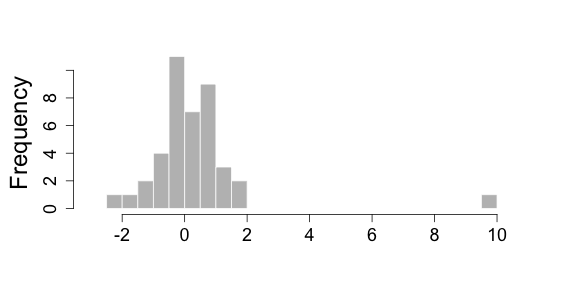

- Technical error?
- Data entry error?
- Unaccounted for tail of data distribution?

### How do most statistics work

Typically, adding up (squared) terms from individual observations to make a *statistic*. Statistic often has useful math properties.

\[ \frac{1}{n} \sum_{i=1}^n y_i \]

\[ \frac{1}{n-1} \sum_{i=1}^n \left( y_i - \bar{y} \right)^2 \]

\[ \sum_{i=1}^n \left( y_i - \hat{\beta}_0 - x_i \hat{\beta}_1 \right)^2 \]

### Median

Mean is typically used to describe the middle instead of median

```r
dat <- matrix(rnorm(5*1e5),ncol=5)
means <- rowMeans(dat)
medians <- apply(dat,1,median)
```

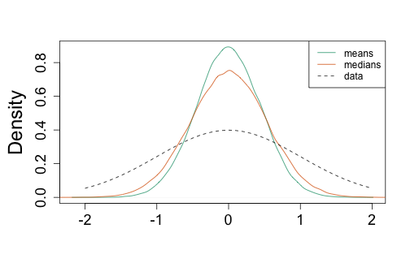

### Efficiency

```r
sd(medians)/sd(means)
```

```
[1] 1.197183
```

### Median for non-normal data

\[ X \sim 95\% \, N(0,1) + 5\% \, N(0,10) \]

```r
dat <- cbind(matrix(rnorm(19*1e5,sd=1),ncol=19),
             matrix(rnorm(1*1e5,sd=10),ncol=1))
means <- rowMeans(dat)
medians <- apply(dat,1,median)
```

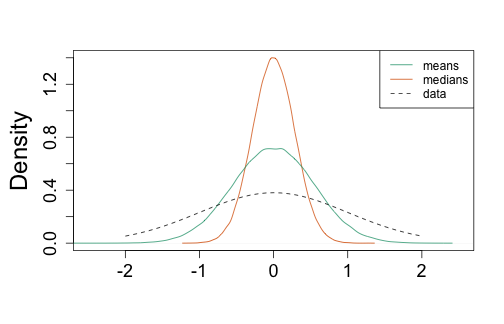

### Trimmed mean for non-normal data

\[ X \sim 95\% \, N(0,1) + 5\% \, N(0,10) \]

```r
dat <- cbind(matrix(rnorm(19*1e5,sd=1),ncol=19),
             matrix(rnorm(1*1e5,sd=10),ncol=1))
means <- rowMeans(dat)
# trim 5% from each end = 10% of data
tmeans <- apply(dat,1,mean,trim=.05)
```

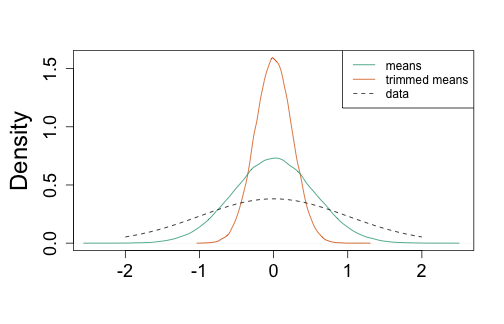

### MAD: median absolute deviation

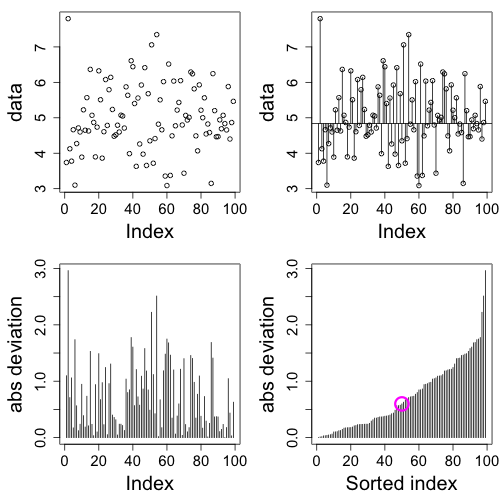

### Median absolute deviation & SD

`mad()` will give you 1.4826 times the median absolute deviation

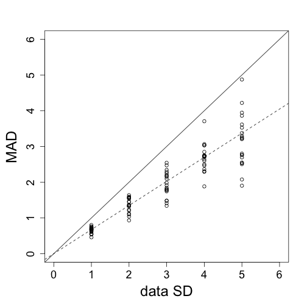

### Efficiency of MAD

```r
dat <- matrix(rnorm(20*1e5),ncol=20)
sds <- apply(dat,1,sd)
mads <- apply(dat,1,mad)
```

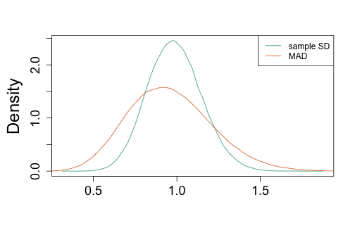

### MAD with outliers

```r
dat <- cbind(matrix(rnorm(19*1e5,sd=1),ncol=19),
             matrix(rnorm(1*1e5,sd=10),ncol=1))
sds <- apply(dat,1,sd)
mads <- apply(dat,1,mad)
```

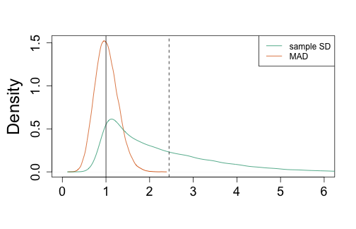

### Spearman correlation

Translate data to ranks and compute correlation

+ less sensitive to outliers

- all subregions of range count equally

### Spearman correlation

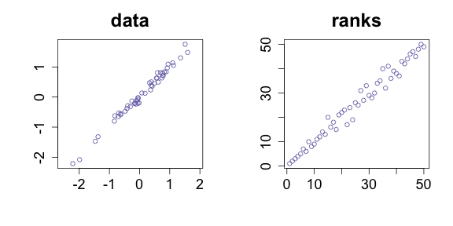

```
  pearson  spearman
0.9932279 0.9879952
```

### Spearman correlation

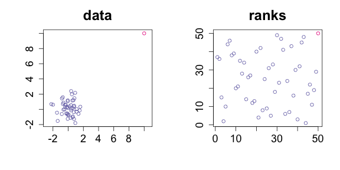

```
    pearson    spearman
 0.69943398 -0.03404562
```

### Spearman correlation

- Drug resistance in cell lines
- Gene expression

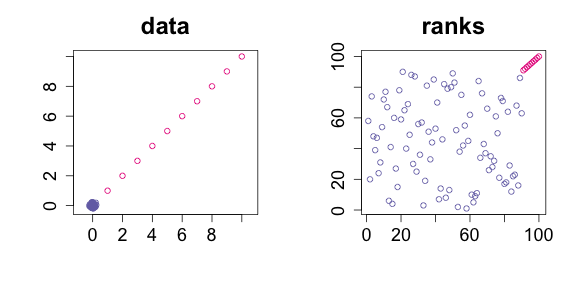

```
  pearson  spearman
0.9977304 0.1939154
```

### Wilcoxon / Mann-Whitney rank test

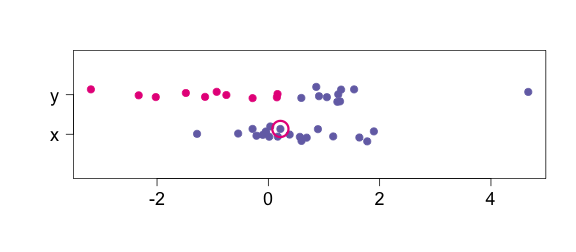

```r
W <- 0
for (i in seq_along(x)) {
  W <- W + sum(y <= x[i])
}
print(W)
```

```
[1] 211
```

### Wilcoxon vs t-test p distribution (n=20)

\[ X \sim N(0,1) \]

\[ Y \sim 90\% \, N(0,1) + 10\% \, N(0,50) \]

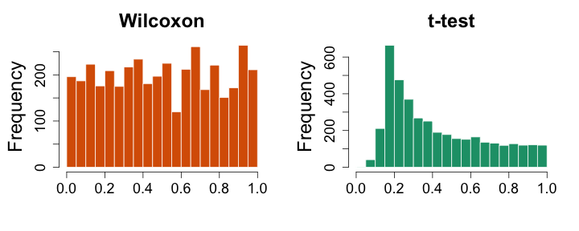

### Wilcoxon vs t-test sensitivity (SD=1, n=4)

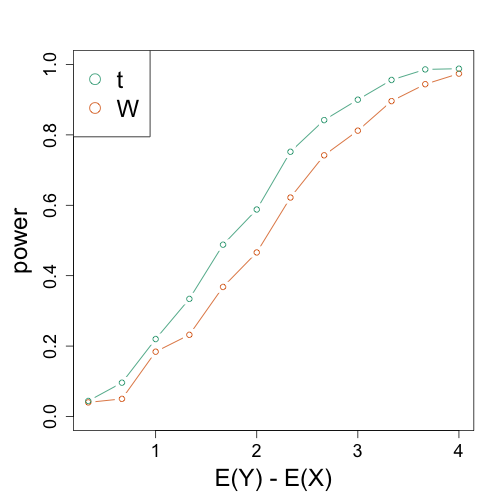

### Wilcoxon for small sample size

```r
wilcox.test(x=101:103, y=1:3)
```

```
    Wilcoxon rank sum test

data:  101:103 and 1:3
W = 9, p-value = 0.1
alternative hypothesis: true location shift is not equal to 0
```

### Weighted least squares

If you know uncertainty associated with each observation \( y_i \)

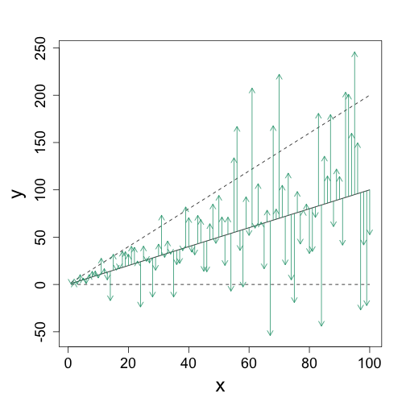

### Weighted least squares

Best linear unbiased estimator is to use

\[ w_i = \frac{1}{\hat{\textrm{Var}}(\varepsilon_i)} \]

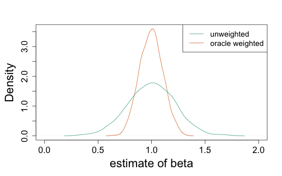

### Cook's distance

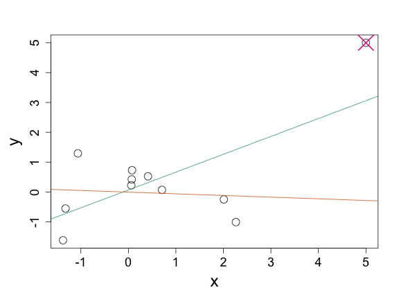

```
                  fit1         fit2
(Intercept) 0.06755603 -0.006076753
x           0.59821827 -0.056409684
```

### Cook's distance

```r
dfbeta(fit1)[1,"x"]
```

```
[1] 0.654628
```

```r
coef(fit1)[2] - coef(fit2)[2]
```

```
       x
0.654628
```

### Cook's distance

```r
cooksD <- cooks.distance(fit1)
```

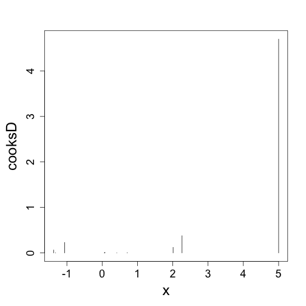

### M-estimators

Because of the squared terms in regression, a few observations with high leverage move the estimated coefficient away from the true value.

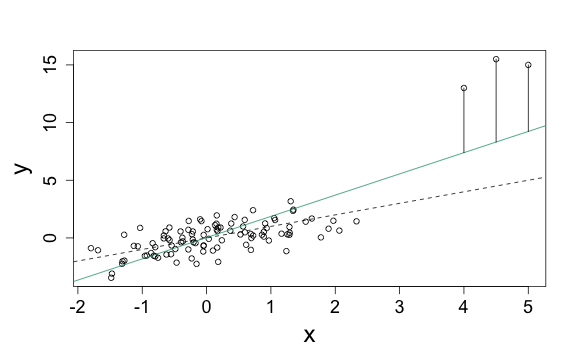

### M-estimators

- M-estimators are a generalized framework for estimation
- M for *Maximum likelihood-type* estimation
- Least squares is a maximum likelihood estimate for data with normally-distributed error.

For data \( Z \) and a parameter \( \theta \) to be estimated:

\[ \hat{\theta}^{\textrm{MLE}} = \textrm{arg max} \sum_i \log f_\theta (z_i) \]

Generalize to *some function* \( \rho \):

\[ \tilde{\theta} = \textrm{arg max} \sum_i \rho_\theta(z_i) \]

### MLE reminder

What are we maximizing with MLE and normal errors?

Something that looks like:

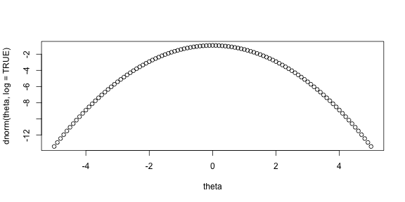

```r
theta <- seq(-5,5,.1)
plot(theta, dnorm(theta,log=TRUE))
```

### Theory of estimation

> It is interesting to look back to the very origin of the theory of estimation, namely to Gauss and his theory of least squares. Gauss was fully aware that his main reason for assuming an underlying normal distribution and a quadratic loss function was mathematical, i.e., **computational, convenience**. In later times, this was often forgotten, partly because of the central limit theorem.

-Huber *Robust Estimation of a Location Parameter* 1964

### Theory of estimation

> However, if one wants to be honest, the central limit theorem can at most explain why many distributions occurring in practice are approximately normal. The stress is on the word “approximately.” This raises a question which could have been asked already by Gauss, but which was, as far as I know, only raised a few years ago (notably by Tukey): **What happens if the true distribution deviates slightly from the assumed normal one**?

-Huber *Robust Estimation of a Location Parameter* 1964

### M-estimators

We want easy derivatives for \( \rho \) so that the minimum can be found using iterative methods like Newton-Raphson. For MLE and normal error this is linear. With M-estimators we have other options.

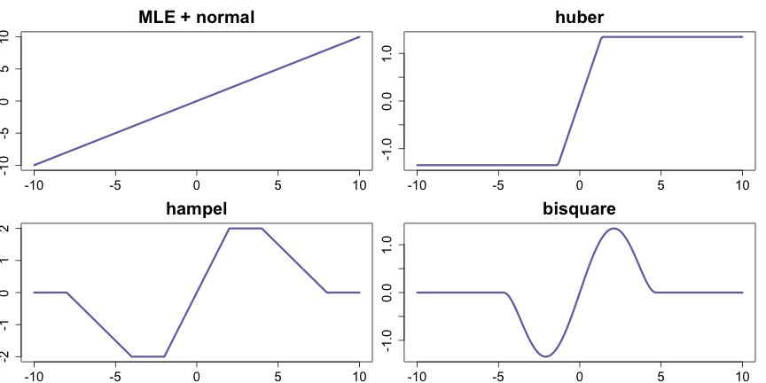

### M-estimators

Venables, W. N. and Ripley, B. D. (2002) *Modern Applied Statistics with S*

```r
library(MASS)
rob.fit <- rlm(y ~ x)
```

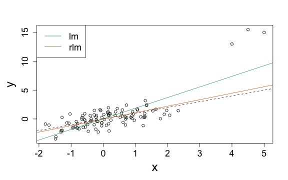

### Links on robust statistics in genomics

- [SAMseq](http://www.ncbi.nlm.nih.gov/pmc/articles/PMC4605138/)'s implementation of rank test
  - sequencing depth
  - noise of low counts
  - false discovery rate
- [voom](https://genomebiology.biomedcentral.com/articles/10.1186/gb-2014-15-2-r29) weighted linear model
- [edgeR](http://nar.oxfordjournals.org/content/42/11/e91) and [limma-voom](http://www.ncbi.nlm.nih.gov/pmc/articles/PMC4551905/) sample quality weights
- [DESeq2](https://genomebiology.biomedcentral.com/articles/10.1186/s13059-014-0550-8) use of Cook's distance